# What Instagram Reels Show Me

## Introduction

This project logs the first Instagram Reel I see each time I open the app. The goal is to explore what kinds of content I’m shown, and how these reels perform in terms of reposts and comments.

The data was collected via a Google Form and includes variables like repost count, comment count, whether hashtags or audio were used, and what type of content the reel featured.

## Most Common Instagram Reel Categories

The chart below shows the frequency of content categories observed in the reels. Meme/humour and relationship content appeared most often. This seems to more or less reflect my tastes in reels. Specifically because I have been interested in relationships more recently.

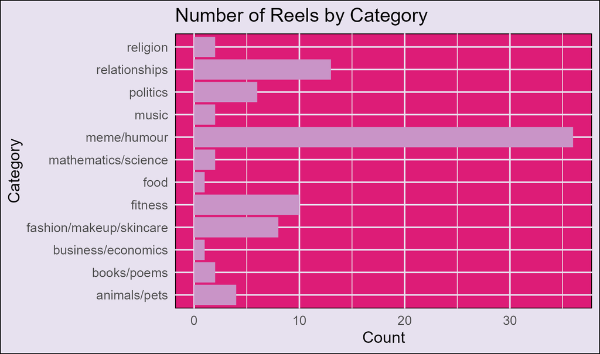

Bar chart showing the number of reels for each category. Meme/humour and relationships are the most common.

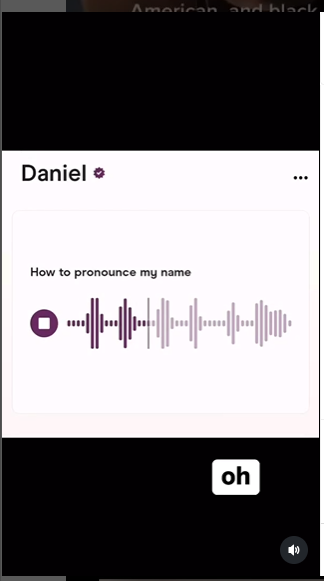

Screenshot of data submission showing a meme/humour and relationships reel - from the dating app hinge.

## Do Hashtags Affect Engagement?

In this boxplot, we compare the number of comments between reels with hashtags and those without. Surprisingly, reels without hashtags tended to receive more comments on average. This could suggest that “organic” content, rather than reels which uses hashtags for reach, might be more engaging. I noticed that when filling out the survey the reels with hashtags tended to be more ’branded” and subjectively seemed less organic.

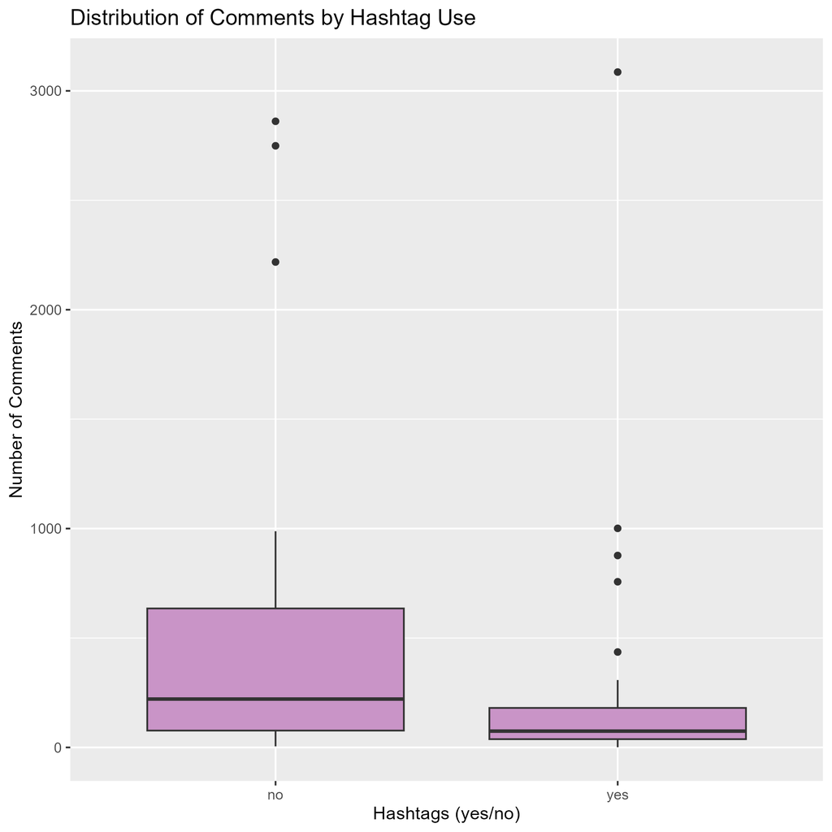

Boxplot showing comments for reels with and without hashtags. Reels without hashtags often receive more comments.

[figure not shown]

Screenshot of a reel with hashtags used.

## How Reposts Changed Over Time

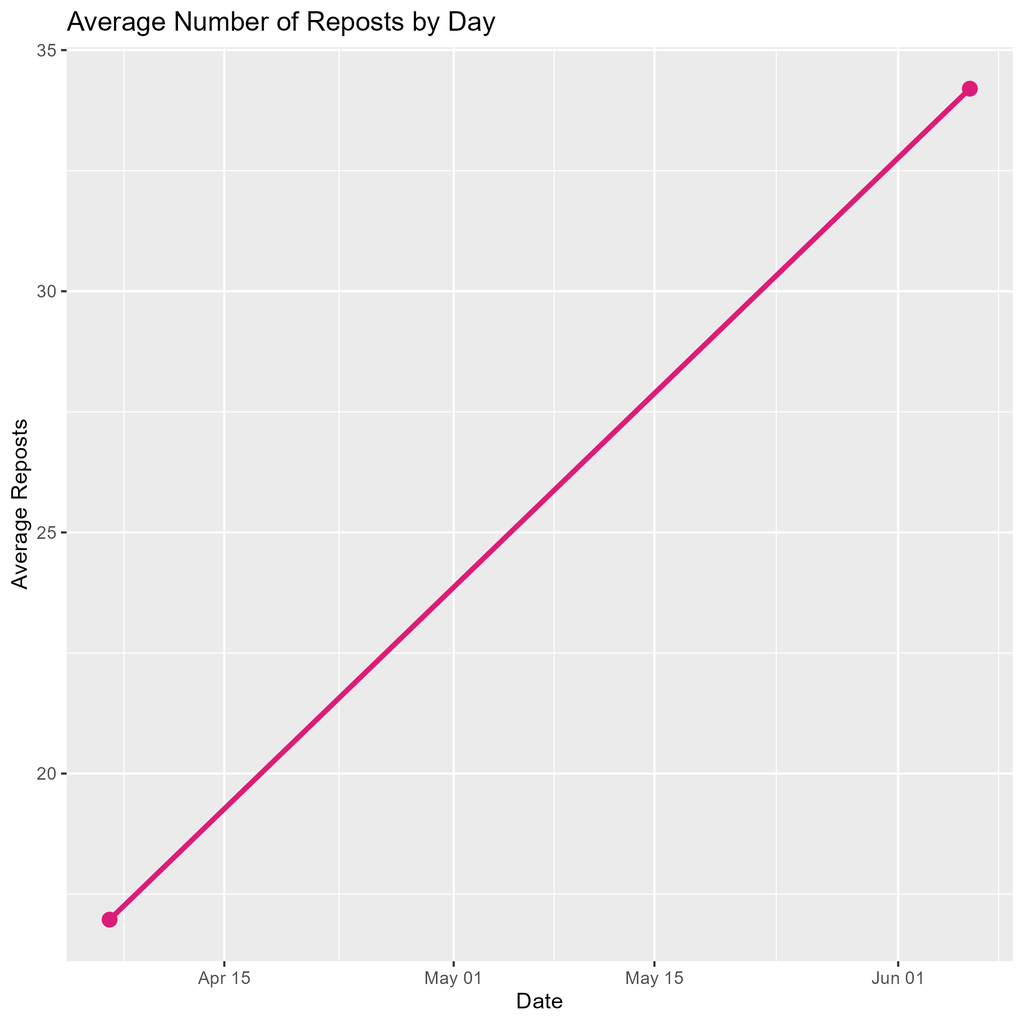

Line plot showing the average number of reposts on different days. June 6 has higher reposts on average.

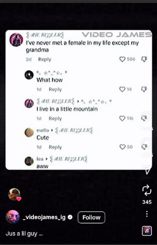

Screenshot of a high-repost reel from June 6.

## Conclusion

From this small observational dataset, it seems that Instagram often shows me reels featuring meme-style content and relationship themes. Interestingly, content without hashtags often attracted more comments, and the amount of reposting increased over time.

From my data collection, I can see how Instagram is customizing the reels I see to my taste, as well as see general trends in reels over time.